# 고급회귀분석 16장

2025-05-04

## 16.5 R 실습

```r
source("functions/mult_reg.R", echo = F)
source("functions/reg_diagnostics.R", echo = F)
source("functions/var_selection.R", echo = F)
source("functions/anova_reg.R", echo = F)
```

이 절에서는 ISLR 패키지에 있는 신용카드 채무 디폴트(default) 자료 (참고문헌 16.3)를 사용하여 로지스틱 회귀모형을 적합하기로 한다. 이 자료는 `student(학생 여부 )`, `income(연간 소득)`과 `balance(월별 신용카드 대금, 단위 : 달러)` 등을 설명변수로 하고, `default(연체 여부)`를 반응변수로 한다. 먼저 `income`과 `balance`에 따른 연체여부를 나타낸 그림을 그려본다.

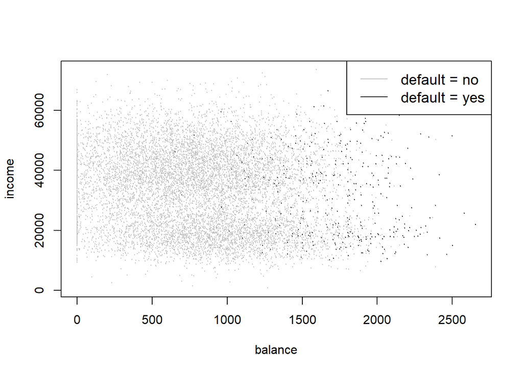

```r
library(ISLR)
plot(income ~ balance, col = ifelse(default == "No", "grey", "black"), cex = 0.1, data = Default)
legend("topright",
       legend = c("default = no", "default = yes"),
       col    = c("grey", "black"),
       lty    = 1,
       cex    = 1.2,
       bg     = "white")
```

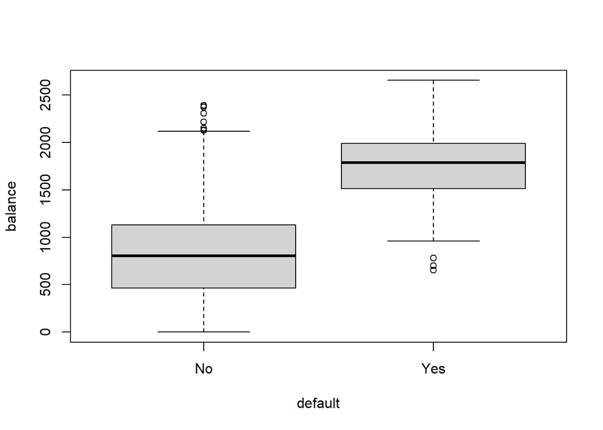

```r
boxplot(balance ~ default, data = Default)
```

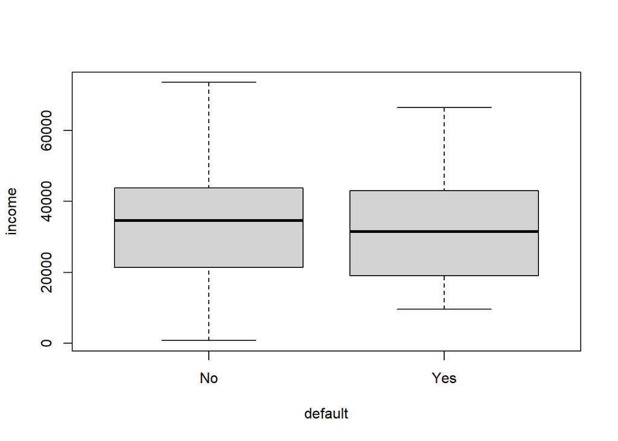

```r
boxplot(income ~ default, data = Default)
```

위 결과를 살펴보면 신용카드 채무가 큰 경우 연체하는 경우가 많음을 알 수 있다. 이에 로지스틱 회귀모형을 다음과 같이 설정해 보자.

$$\begin{equation*}
\log \left[ \cfrac{P(\text{default = yes} |
\text{balance})}{P(\text{default = no} | \text{balance})} \right] =
\beta_0 + \beta_1 \times \text{balance}
\end{equation*}$$
위 모형에 대한 `R`적합은 다음과 같다.

```r
glm.fit <- glm(default ~ balance, data = Default, family = binomial)
summary(glm.fit)
```

```
##
## Call:
## glm(formula = default ~ balance, family = binomial, data = Default)
##
## Coefficients:
##               Estimate Std. Error z value Pr(>|z|)
## (Intercept) -1.065e+01  3.612e-01  -29.49   <2e-16 ***
## balance      5.499e-03  2.204e-04   24.95   <2e-16 ***
## ---
## Signif. codes:  0 '***' 0.001 '**' 0.01 '*' 0.05 '.' 0.1 ' ' 1
##
## (Dispersion parameter for binomial family taken to be 1)
##
##     Null deviance: 2920.6  on 9999  degrees of freedom
## Residual deviance: 1596.5  on 9998  degrees of freedom
## AIC: 1600.5
##
## Number of Fisher Scoring iterations: 8
```

여기서 $\hat{\beta}_0 = -10.6513$ 이라는 것은 `balance`가 0달러일 때, 디폴트에 대한 로그 오즈가 -10.6513 혹은 오즈가 $e^{-10.6513} = 2.4 \times 10^{-5}$라는 뜻이다. $\hat{\beta}_1 = 0.0055$라는 것은 `balance`가 1달러 증가할 때 디폴트에 대한 로그 오즈가 0.0055씩 증가한다는 뜻이다. 이들 추정량에 대한 표준오차를 이용하여 $\beta_0$와 $\beta_1$에 대한 가설검정과 신뢰구간을 구할 수 있다. 이제 좀 더 구체적으로 `balance`에 따라 디폴트가 될 확률을 추정해 보자. 로지스틱 회귀모형으로부터 디폴트가 될 확률은 다음과 같다.

$$\begin{equation*}
\hat{P}(\text{default = yes} | \text{balance}) =
\cfrac{e^{\hat{\beta}_0 + \hat{\beta}_1 \times \text{balance}}}{1 +
e^{\hat{\beta}_0 + \hat{\beta}_1 \times \text{balance}}}
\end{equation*}$$

위 식에서 `balance = 1000` 달러일때, 디폴트가 될 확률은 0.00576으로 1%도 되지 않는 것을 알 수 있다. 그러나 `balance = 2000` 달러일때에는 디폴트가 될 확률이 0.586으로 58.6%가 되는 것을 알 수 있다.

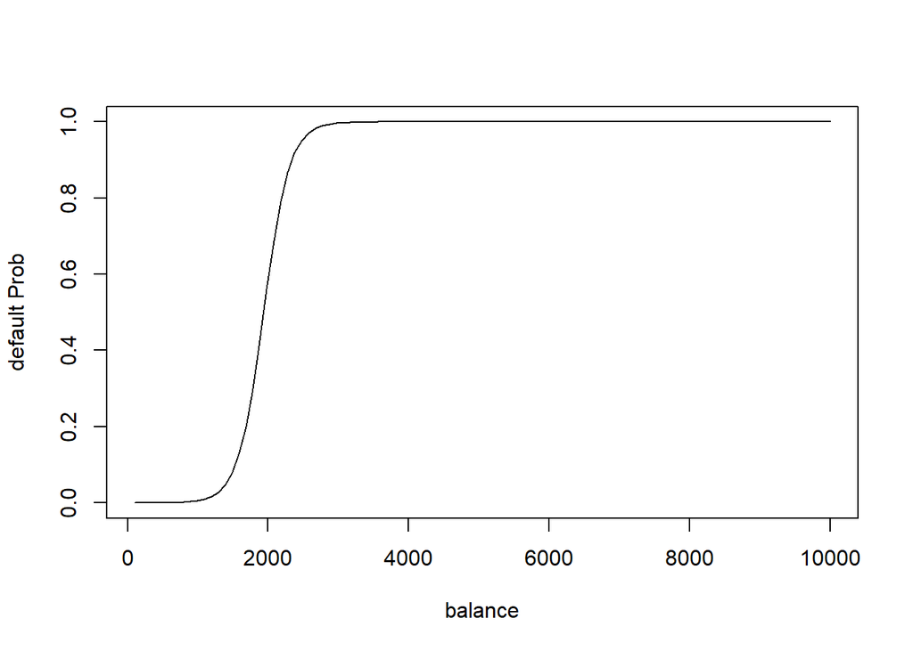

```r
glm_coef = glm.fit$coefficients
curve(expr = exp(glm_coef[1] + glm_coef[2] * x) / (1 + exp(glm_coef[1] + glm_coef[2] * x)), from = 100, to = 10000, n = 101, xlab = "balance", ylab = "default Prob")
```

이번에는 `balance`와 같은 연속형 예측변수 대신 `student`와 같은 이진형 변수를 사용한 경우를 살펴보자.

```r
glm.fit <- glm(default ~ student, data = Default, family = binomial)
summary(glm.fit)
```

```
##
## Call:
## glm(formula = default ~ student, family = binomial, data = Default)
##
## Coefficients:
##             Estimate Std. Error z value Pr(>|z|)
## (Intercept) -3.50413    0.07071  -49.55  < 2e-16 ***
## studentYes   0.40489    0.11502    3.52 0.000431 ***
## ---
## Signif. codes:  0 '***' 0.001 '**' 0.01 '*' 0.05 '.' 0.1 ' ' 1
##
## (Dispersion parameter for binomial family taken to be 1)
##
##     Null deviance: 2920.6  on 9999  degrees of freedom
## Residual deviance: 2908.7  on 9998  degrees of freedom
## AIC: 2912.7
##
## Number of Fisher Scoring iterations: 6
```

위 결과로부터 학생이 아닌 경우에 비해 학생인 경우 디폴트 될 확률이 크다는 것을 알 수 있다.

이제 다음의 다중 로지스틱 회귀모형(multiple logistice regression model)을 적합해 보자.

$$\begin{equation*}
\log \left[ \cfrac{P(\text{default = yes} | \text{balance, income,
student})}{P(\text{default = no} | \text{balance, income, student})}
\right] = \beta_0 + \beta_1 \times \text{balance} + \beta_2 \times
\text{income} + \beta_3 \times \text{student}
\end{equation*}$$

```r
mglm.fit <- glm(default ~ balance + income + student, data = Default, family = binomial)
summary(mglm.fit)
```

```
##
## Call:
## glm(formula = default ~ balance + income + student, family = binomial,
##     data = Default)
##
## Coefficients:
##               Estimate Std. Error z value Pr(>|z|)
## (Intercept) -1.087e+01  4.923e-01 -22.080  < 2e-16 ***
## balance      5.737e-03  2.319e-04  24.738  < 2e-16 ***
## income       3.033e-06  8.203e-06   0.370  0.71152
## studentYes  -6.468e-01  2.363e-01  -2.738  0.00619 **
## ---
## Signif. codes:  0 '***' 0.001 '**' 0.01 '*' 0.05 '.' 0.1 ' ' 1
##
## (Dispersion parameter for binomial family taken to be 1)
##
##     Null deviance: 2920.6  on 9999  degrees of freedom
## Residual deviance: 1571.5  on 9996  degrees of freedom
## AIC: 1579.5
##
## Number of Fisher Scoring iterations: 8
```

`student`를 예측변수로 한 경우 회귀계수는 양수로 학생인 경우 연체할 가능성이 큰 것으로 나타났는데, 다른 변수를 포함시킨 경우에는 `student`의 회귀계수는 음수로 학생인 경우 연체할 가능성이 줄어드는 것으로 나타났다. 이러한 현상을 어떻게 설명해야 할까?

이를 설명하기 위해 다중 로지스틱 회귀모형에서 `income`은 평균으로 고정하고 학생인 경우와 학생이 아닌 경우를 나누어 디폴트일 확률을 구해 보았다.

```r
yes.dat <- data.frame(balance = 0:2655, income = mean(Default$income), student = "Yes")
no.dat <- data.frame(balance = 0:2655, income = mean(Default$income), student = "No")
yes.prob <- predict(mglm.fit, yes.dat, type = "response")
no.prob <- predict(mglm.fit, no.dat, type = "response")
```

여기서 `yes.dat, no.dat`은 각각 `income`을 평균으로 하고, `balance`는 자료의 최솟값과 최댓값에 대하여 변화하면서 `student = yes`인 경우, `student = no`인 경우로 생성한 새로운 자료를 나타낸다. `predict()`함수를 사용하여 각 경우에 대한 디폴트 확률을 구하여 `yes.prob`과 `no.prob`에 저장하였다. 이에 대한 그림을 살펴보면 다음과 같다.

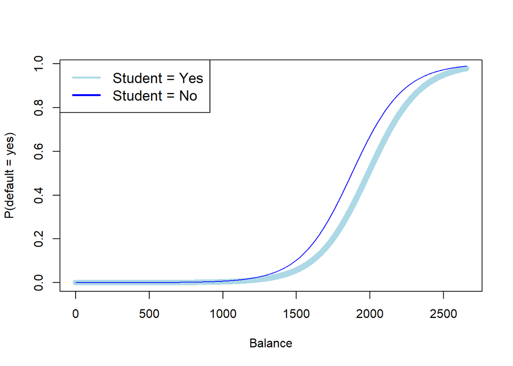

```r
x =c(0 : 2655)
plot(x = x, y = yes.prob, col = "lightblue", lwd = 1.0,
     xlab  = "Balance", ylab = "P(default = yes)")
# 2) 두 번째 곡선 추가
lines(x, no.prob, col = "blue", lwd = 1.0)
legend("topleft",
       legend = c("Student = Yes", "Student = No"),
       col    = c("lightblue", "blue"),
       lty    = 1,
       lwd    = 2.5,
       cex    = 1.2,
       bg     = "white")
```

즉 학생여부와 상관없이 `balance`가 커짐에 따라 디폴트 확률이 커짐을 알 수 있다. 또한 이 경우 `balance`를 고정하고 보면 학생이 아닌 경우가 학생인 경우보다 디폴트 확률이 크다는 것을 알 수 있다. 이러한 현상은 `balance`와 `income`을 고객들의 평균으로 고정하고 학생인 경우와 학생이 아닌 경우를 비교해 보아도 학생이 아닌 경우 연체할 가능성이 크다는 것을 알 수 있다.

```r
yes.dat2 <- data.frame(balance = mean(Default$balance),
                       income = mean(Default$income), student = "Yes")
no.dat2 <- data.frame(balance = mean(Default$balance),
                       income = mean(Default$income), student = "No")
yes2.prob <- predict(mglm.fit, yes.dat2, type = "response")
no2.prob <- predict(mglm.fit, no.dat2, type = "response")

yes2.prob ; no2.prob
```

```
##           1
## 0.001328976
```

```
##           1
## 0.002534451
```

그런데, 다음의 상자그림을 보면 학생은 학생이 아닌 사람보다 많은 부채(`balance`)를 지고 있는 것을 알 수 있다. 이런 경우에 `student`만을 예측변수로 두게 되면 `balance`의 영향을 무시하게 되어 학생의 연체 여부에 부채의 효과가 함께 나타나게 된다. 다시 말해, `student`만을 설명변수로 사용한 경우 회귀계수 효과에는 `balance`의 효과가 교락(confounding)되기 때문에, `student`만을 설명변수로 사용한 회귀계수 추정값과, `balance`도 예측변수로 포함한 모형에서의 `student`회귀계수 추정값은 부호가 달라지는 현상이 발생할 수 있다. 이러한 현상을 심슨의 패러독스(Simpson’s paradox)라고 한다. 따라서, `balance`의 정보가 있는 경우 다중 로지스틱 회귀모형을 통해 다른 변수들의 값이 동일한 일반인보다 학생이 연체가능성이 작다고 평가할 수 있다.

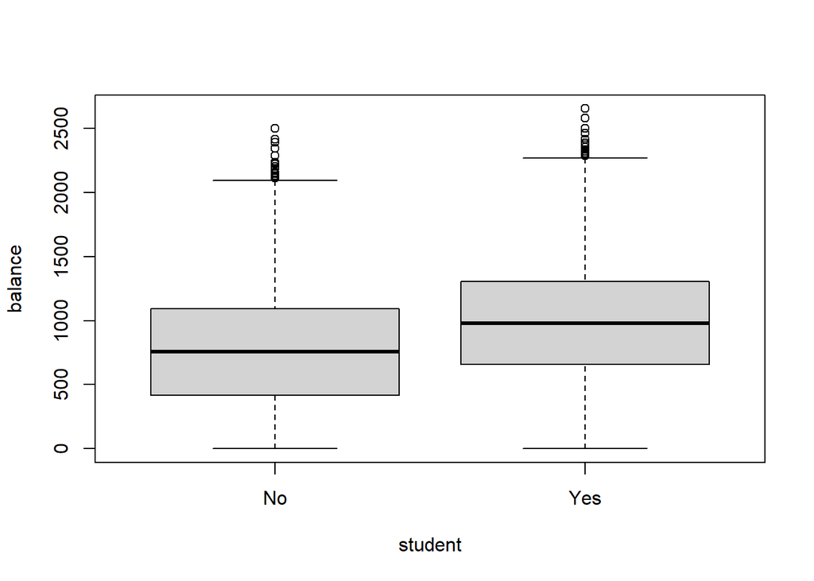

```r
boxplot(balance ~ student, data = Default)
```

## 연습문제

### 16.1

```r
x = c(410, 500, 471, 619, 584, 681, 399, 481, 624, 589)
y = c(0, 1, 0, 1, 0, 1, 0, 1, 1, 1)
```

#### 16.1 - (1)

```r
X = cbind(x)
reg_res = mult_reg(X, y, alpha = 0.05, coeff = TRUE)
```

```
##   요인   제곱합 자유도 평균제곱합      F값  F기각치
## 1 회귀 0.928432      1   0.928432 5.047308 5.317655
## 2 잔차 1.471568      8   0.183946       NA       NA
## 3   계 2.400000      9         NA       NA       NA
## SST = 2.4, SSR = 0.928432045125393, SSE = 1.47156795487461
## MSR = 0.928432045125393, MSE = 0.183945994359326
## F_0 = 5.04730776203675, F_alpha = 5.31765507157871
```

```r
reg_res$beta_hat
```

```
##            [,1]
## one -1.18171164
## x    0.00332533
```

#### 16.1 - (2)

```r
source("functions/mult_reg.R", echo = FALSE)

IRWLS_res = irwls_logistic_reg(X, y)
```

```
## computing at 1 iterations
## supreme norm distance = 6.72684655842673
## computing at 2 iterations
## supreme norm distance = 2.13156327028401
## computing at 3 iterations
## supreme norm distance = 0.497050739386683
## computing at 4 iterations
## supreme norm distance = 0.0261538426172319
## computing at 5 iterations
## supreme norm distance = 7.27957702757465e-05
## converged at 6 iterations
## supreme norm distance = 5.79948533641073e-10
##            [,1]
## one -9.38168721
## x    0.01873945
```

#### 16.1 - (3)

```r
simp_res = mult_reg(X, y, alpha = 0.05, coeff = TRUE)
```

```
##   요인   제곱합 자유도 평균제곱합      F값  F기각치
## 1 회귀 0.928432      1   0.928432 5.047308 5.317655
## 2 잔차 1.471568      8   0.183946       NA       NA
## 3   계 2.400000      9         NA       NA       NA
## SST = 2.4, SSR = 0.928432045125393, SSE = 1.47156795487461
## MSR = 0.928432045125393, MSE = 0.183945994359326
## F_0 = 5.04730776203675, F_alpha = 5.31765507157871
```

```r
MSE = simp_res$MSE
W = IRWLS_res$W

one = c(rep(1, length(x)))
X = cbind(one, x)
## 단순회귀 beta_hat 분산
var_beta_hat_LSE = MSE * solve(t(X) %*% X)

## IRWLS beta_hat 분산
var_beta_hat_IRWLS = solve(t(X) %*% W %*% X)

var_beta_hat_LSE ; var_beta_hat_IRWLS
```

```
##              one             x
## one  0.647343044 -1.173849e-03
## x   -0.001173849  2.190835e-06
```

```
##             one             x
## one 33.54595892 -0.0642870383
## x   -0.06428704  0.0001257899
```

#### 16.1 - (4)

```r
beta_hat_IRWLS = IRWLS_res$beta_hat


score = t(c(1, 550)) %*% beta_hat_IRWLS
p_hat_y_1_x_500 = exp(score) / (1 + exp(score))
p_hat_y_1_x_500
```

```
##           [,1]
## [1,] 0.7160622
```

#### 번외 - ISLR Default 데이터셋에 대한 IRWLS

```r
library(ISLR)
library(dplyr)
dataset_default = Default %>% na.omit()

X = dataset_default %>%
  dplyr::select(balance:income)
y = ifelse(dataset_default$default == "Yes", 1, 0)

X = as.matrix(X)

default_irwls_res = irwls_logistic_reg(X, y, tol = 1e-8)
```

```
## computing at 1 iterations
## supreme norm distance = 2.36895873474465
## computing at 2 iterations
## supreme norm distance = 1.82532082599086
## computing at 3 iterations
## supreme norm distance = 2.21801516728202
## computing at 4 iterations
## supreme norm distance = 2.30090712675809
## computing at 5 iterations
## supreme norm distance = 1.84384984813114
## computing at 6 iterations
## supreme norm distance = 0.850886047690532
## computing at 7 iterations
## supreme norm distance = 0.129976739818325
## computing at 8 iterations
## supreme norm distance = 0.00255299226559025
## computing at 9 iterations
## supreme norm distance = 9.67253232175835e-07
## converged at 10 iterations
## supreme norm distance = 1.3855583347322e-13
##                  [,1]
## one     -1.154047e+01
## balance  5.647103e-03
## income   2.080898e-05
```

```r
glm_res <- glm(default ~ balance + income, data = Default, family = binomial)
glm_res$coefficients
```

```
##   (Intercept)       balance        income
## -1.154047e+01  5.647103e-03  2.080898e-05
```

신용불량 데이터셋에 대해서 `irwls_logistic_reg()`함수와 `glm()`함수에서 적합된 회귀계수를 비교해보면 서로 같음을 확인할 수 있다. 이를 통해 `glm()`함수는 내부적으로 IRWLS 알고리즘을 통해 로지스틱 회귀모형을 적합시키는 것을 알 수 있다. 다만 수렴속도가 굉장히 빠른 것으로 보아 Rcpp등의 계산속도 향상이 이뤄지는 코드가 추가된게 `glm()`이라는 것 같다.

```r
summary(glm_res)
```

```
##
## Call:
## glm(formula = default ~ balance + income, family = binomial,
##     data = Default)
##
## Coefficients:
##               Estimate Std. Error z value Pr(>|z|)
## (Intercept) -1.154e+01  4.348e-01 -26.545  < 2e-16 ***
## balance      5.647e-03  2.274e-04  24.836  < 2e-16 ***
## income       2.081e-05  4.985e-06   4.174 2.99e-05 ***
## ---
## Signif. codes:  0 '***' 0.001 '**' 0.01 '*' 0.05 '.' 0.1 ' ' 1
##
## (Dispersion parameter for binomial family taken to be 1)
##
##     Null deviance: 2920.6  on 9999  degrees of freedom
## Residual deviance: 1579.0  on 9997  degrees of freedom
## AIC: 1585
##
## Number of Fisher Scoring iterations: 8
```

```r
anova(glm_res)
```

```
## Analysis of Deviance Table
##
## Model: binomial, link: logit
##
## Response: default
##
## Terms added sequentially (first to last)
##
##
##         Df Deviance Resid. Df Resid. Dev  Pr(>Chi)
## NULL                     9999     2920.7
## balance  1  1324.20      9998     1596.5 < 2.2e-16 ***
## income   1    17.49      9997     1579.0 2.895e-05 ***
## ---
## Signif. codes:  0 '***' 0.001 '**' 0.01 '*' 0.05 '.' 0.1 ' ' 1
```

### 16.2

```r
x = c(12, 15, 42, 52, 59, 73, 82, 91, 96, 105, 114, 120, 121, 128, 130, 139, 139, 157,
      1, 1, 2, 8, 11, 18, 22, 31, 37, 61, 72, 81, 97, 112, 118, 127, 131, 140, 151, 159, 177, 206)
y = c(rep(1, 18), rep(0, 22))
```

#### 16.2 - (1)

```r
X = cbind(x)
IRWLS_res = irwls_logistic_reg(X, y)
```

```
## computing at 1 iterations
## supreme norm distance = 0.562154344622992
## computing at 2 iterations
## supreme norm distance = 0.0105283165189186
## computing at 3 iterations
## supreme norm distance = 1.04449683286933e-05
## converged at 4 iterations
## supreme norm distance = 1.03710373622334e-11
##             [,1]
## one -0.572693106
## x    0.004295787
```

```r
GLM_res = glm(y ~ x, family = binomial)
GLM_res$coefficients
```

```
##  (Intercept)            x
## -0.572693106  0.004295787
```

```r
summary(GLM_res)
```

```
##
## Call:
## glm(formula = y ~ x, family = binomial)
##
## Coefficients:
##              Estimate Std. Error z value Pr(>|z|)
## (Intercept) -0.572693   0.602395  -0.951    0.342
## x            0.004296   0.005849   0.734    0.463
##
## (Dispersion parameter for binomial family taken to be 1)
##
##     Null deviance: 55.051  on 39  degrees of freedom
## Residual deviance: 54.504  on 38  degrees of freedom
## AIC: 58.504
##
## Number of Fisher Scoring iterations: 4
```

```r
anova(GLM_res)
```

```
## Analysis of Deviance Table
##
## Model: binomial, link: logit
##
## Response: y
##
## Terms added sequentially (first to last)
##
##
##      Df Deviance Resid. Df Resid. Dev Pr(>Chi)
## NULL                    39     55.051
## x     1  0.54689        38     54.504   0.4596
```

#### 16.2 - (2)

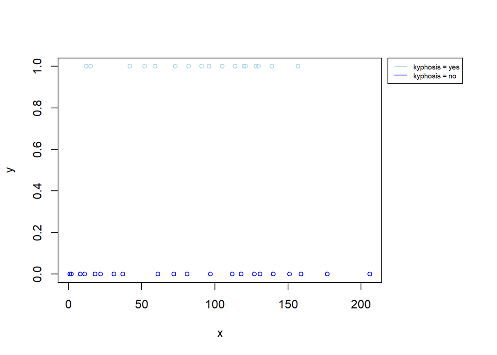

```r
op <- par(no.readonly = TRUE)
par(mar = c(5, 4, 4, 8) + 0.1)
plot(y ~ x, col = ifelse(y == 1, "lightblue", "blue"), cex = 0.85)
par(xpd = NA)
legend("topright",
       legend = c("kyphosis = yes", "kyphosis = no"),
       inset  = c(-0.25, 0),
       col    = c("lightblue", "blue"),
       lty    = 1,
       cex    = 0.6,
       bg     = "white")
```

```r
par(op)
```

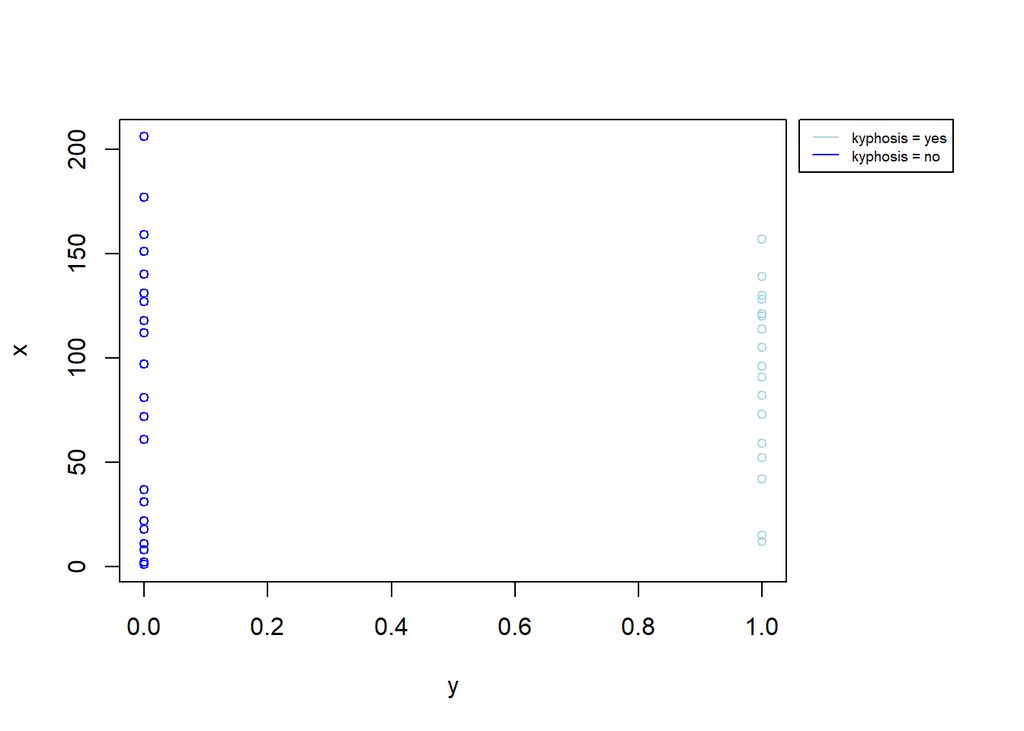

```r
op <- par(no.readonly = TRUE)
par(mar = c(5, 4, 4, 8) + 0.1)
plot(x ~ y, col = ifelse(y == 1, "lightblue", "blue"), cex = 0.85)
par(xpd = NA)
legend("topright",
       legend = c("kyphosis = yes", "kyphosis = no"),
       inset  = c(-0.25, 0),
       col    = c("lightblue", "blue"),
       lty    = 1,
       cex    = 0.6,
       bg     = "white")
```

```r
par(op)
```

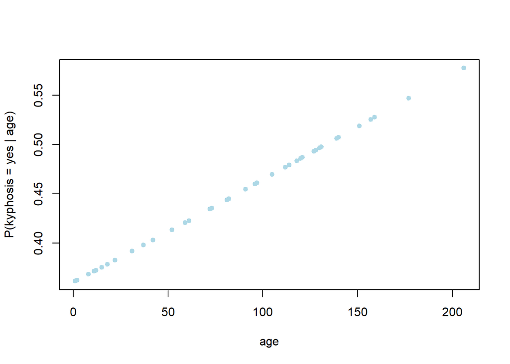

```r
X_df = data.frame(X)
kyphosis_yes_prob = predict(GLM_res, X_df, type = "response")

plot(x = x, y = kyphosis_yes_prob, xlab = "age", ylab = "P(kyphosis = yes | age)",
     lwd = 1.0, col = "lightblue", cex = 0.8, pch = 21, bg  = "lightblue")
```

#### 16.2 - (3)

```r
X = cbind(x, x^2)
colnames(X) = c("age", "age^2")

IRWLS_res = irwls_logistic_reg(X, y)
```

```
## computing at 1 iterations
## supreme norm distance = 1.6212532695416
## computing at 2 iterations
## supreme norm distance = 0.372550894858426
## computing at 3 iterations
## supreme norm distance = 0.0514738590712516
## computing at 4 iterations
## supreme norm distance = 0.000976277596735908
## computing at 5 iterations
## supreme norm distance = 3.72606470566694e-07
## converged at 6 iterations
## supreme norm distance = 5.90638649100583e-14
##                [,1]
## one   -2.0462546737
## age    0.0600397937
## age^2 -0.0003279439
```

```r
GLM_res = glm(y ~ X, family = binomial)
GLM_res$coefficients
```

```
##   (Intercept)          Xage        Xage^2
## -2.0462546726  0.0600397937 -0.0003279439
```

```r
summary(GLM_res)
```

```
##
## Call:
## glm(formula = y ~ X, family = binomial)
##
## Coefficients:
##               Estimate Std. Error z value Pr(>|z|)
## (Intercept) -2.0462547  0.9943478  -2.058   0.0396 *
## Xage         0.0600398  0.0267808   2.242   0.0250 *
## Xage^2      -0.0003279  0.0001564  -2.097   0.0360 *
## ---
## Signif. codes:  0 '***' 0.001 '**' 0.01 '*' 0.05 '.' 0.1 ' ' 1
##
## (Dispersion parameter for binomial family taken to be 1)
##
##     Null deviance: 55.051  on 39  degrees of freedom
## Residual deviance: 48.228  on 37  degrees of freedom
## AIC: 54.228
##
## Number of Fisher Scoring iterations: 4
```

```r
anova(GLM_res)
```

```
## Analysis of Deviance Table
##
## Model: binomial, link: logit
##
## Response: y
##
## Terms added sequentially (first to last)
##
##
##      Df Deviance Resid. Df Resid. Dev Pr(>Chi)
## NULL                    39     55.051
## X     2   6.8231        37     48.228  0.03299 *
## ---
## Signif. codes:  0 '***' 0.001 '**' 0.01 '*' 0.05 '.' 0.1 ' ' 1
```

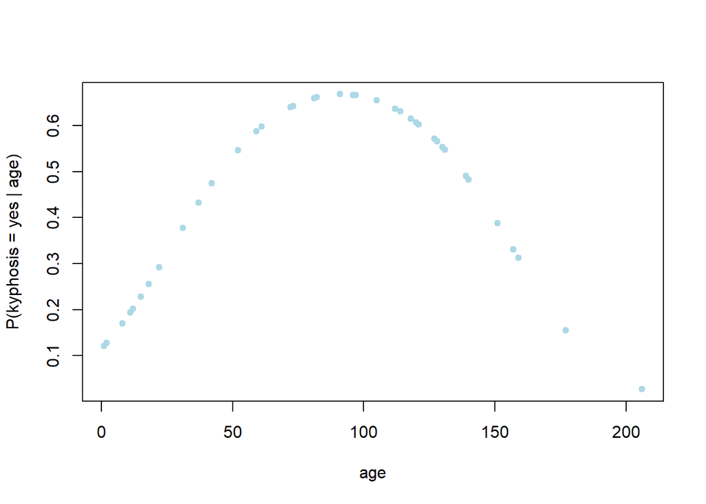

```r
X_df = data.frame(X)
kyphosis_yes_prob = predict(GLM_res, X_df, type = "response")

plot(x = x, y = kyphosis_yes_prob, xlab = "age", ylab = "P(kyphosis = yes | age)",
     lwd = 1.0, col = "lightblue", cex = 0.8, pch = 21, bg  = "lightblue")
```

### 16.6

```r
x11 = c(rep(1, 484)) ; y11 = c(rep(1, 484))
x12 = c(rep(1, 27)) ; y12 = c(rep(0, 27))
x21 = c(rep(0, 385)) ; y21 = c(rep(1, 385))
x22 = c(rep(0, 90)) ; y22 = c(rep(0, 90))

x = c(x11, x12, x21, x22) ; y = c(y11, y12, y21, y22)

X = cbind(x)

IRWLS_res = irwls_logistic_reg(X, y)
```

```
## computing at 1 iterations
## supreme norm distance = 1.24210526315789
## computing at 2 iterations
## supreme norm distance = 0.537650637127777
## computing at 3 iterations
## supreme norm distance = 0.297658147592696
## computing at 4 iterations
## supreme norm distance = 0.0498195780674755
## computing at 5 iterations
## supreme norm distance = 0.00114098817920105
## computing at 6 iterations
## supreme norm distance = 5.82487404754417e-07
## converged at 7 iterations
## supreme norm distance = 1.65201186064223e-13
##         [,1]
## one 1.453434
## x   1.432814
```

```r
GLM_res = glm(y ~ X, family = binomial)
GLM_res$coefficients
```

```
## (Intercept)           X
##    1.453434    1.432814
```

```r
summary(GLM_res)
```

```
##
## Call:
## glm(formula = y ~ X, family = binomial)
##
## Coefficients:
##             Estimate Std. Error z value Pr(>|z|)
## (Intercept)   1.4534     0.1171  12.414  < 2e-16 ***
## X             1.4328     0.2298   6.235 4.52e-10 ***
## ---
## Signif. codes:  0 '***' 0.001 '**' 0.01 '*' 0.05 '.' 0.1 ' ' 1
##
## (Dispersion parameter for binomial family taken to be 1)
##
##     Null deviance: 718.30  on 985  degrees of freedom
## Residual deviance: 672.52  on 984  degrees of freedom
## AIC: 676.52
##
## Number of Fisher Scoring iterations: 5
```

```r
anova(GLM_res)
```

```
## Analysis of Deviance Table
##
## Model: binomial, link: logit
##
## Response: y
##
## Terms added sequentially (first to last)
##
##
##      Df Deviance Resid. Df Resid. Dev  Pr(>Chi)
## NULL                   985     718.30
## X     1   45.777       984     672.52 1.325e-11 ***
## ---
## Signif. codes:  0 '***' 0.001 '**' 0.01 '*' 0.05 '.' 0.1 ' ' 1
```

거꾸로 해본다 (분석결과가 이상하므로)

```r
x11 = c(rep(1, 484)) ; y11 = c(rep(1, 484))
x12 = c(rep(1, 27)) ; y12 = c(rep(0, 27))
x21 = c(rep(0, 385)) ; y21 = c(rep(1, 385))
x22 = c(rep(0, 90)) ; y22 = c(rep(0, 90))

y = c(x11, x12, x21, x22) ; x = c(y11, y12, y21, y22)

X = cbind(x)

IRWLS_res = irwls_logistic_reg(X, y)
```

```
## computing at 1 iterations
## supreme norm distance = 1.30477117818889
## computing at 2 iterations
## supreme norm distance = 0.124033543620785
## computing at 3 iterations
## supreme norm distance = 0.00400533729131491
## computing at 4 iterations
## supreme norm distance = 4.31764877251162e-06
## converged at 5 iterations
## supreme norm distance = 5.03619368430464e-12
##          [,1]
## one -1.203973
## x    1.432814
```

```r
GLM_res = glm(y ~ X, family = binomial)
GLM_res$coefficients
```

```
## (Intercept)           X
##   -1.203973    1.432814
```

```r
summary(GLM_res)
```

```
##
## Call:
## glm(formula = y ~ X, family = binomial)
##
## Coefficients:
##             Estimate Std. Error z value Pr(>|z|)
## (Intercept)  -1.2040     0.2194  -5.487 4.09e-08 ***
## X             1.4328     0.2298   6.235 4.52e-10 ***
## ---
## Signif. codes:  0 '***' 0.001 '**' 0.01 '*' 0.05 '.' 0.1 ' ' 1
##
## (Dispersion parameter for binomial family taken to be 1)
##
##     Null deviance: 1365.6  on 985  degrees of freedom
## Residual deviance: 1319.8  on 984  degrees of freedom
## AIC: 1323.8
##
## Number of Fisher Scoring iterations: 4
```

```r
anova(GLM_res)
```

```
## Analysis of Deviance Table
##
## Model: binomial, link: logit
##
## Response: y
##
## Terms added sequentially (first to last)
##
##
##      Df Deviance Resid. Df Resid. Dev  Pr(>Chi)
## NULL                   985     1365.6
## X     1   45.777       984     1319.8 1.325e-11 ***
## ---
## Signif. codes:  0 '***' 0.001 '**' 0.01 '*' 0.05 '.' 0.1 ' ' 1
```